# HW-3

Oya Hoban

2024-01-16

In Homework-3 of IE-582, we are required to conduct an experiment on Clustering and Estimation of Mixture of Multivariate Normal Distributions. Firstly, 500 data points with 8 variables, each with 4 different parameter settings has been generated, resulting with 2000 data points in total. Unsupervised random forest is trained to determine the similarity between 2000 observations. After transforming similarity to dissimilarity, two clustering approaches (partitioning around medoids and hierarchical clustering with Ward’s method) are applied to achieve four clusters. K-means clustering is applied to the raw data for baseline comparison. The performance of the strategies is further evaluated by introducing additional noise variables from a Bernoulli distribution.

1- Generate 500 data points with 8 variables with 4 different parameter settings (i.e. covariance and mean).

```r
set.seed(331)

nofsample <- 500
nvar<-8
mean_data <- rbind(c(5,6,4,3,2,5,3,1),c(3,3,3,3,3,3,3,3),c(4,1,2,5,6,9,3,4),c(4,4,4,4,3,3,2,2))
cov_data = c(4,5,2,1)

for (i in 1:4){

mu=mean_data[i,]
# Generate a random positive definite covariance matrix

cov_matrix <- matrix(0,nvar,nvar)
diag(cov_matrix)=cov_data[i]
temp <- mvrnorm(nofsample, mu, cov_matrix)

assign(paste0("data_", i),temp)

}

data_combined <- rbind(data_1,data_2,data_3,data_4)
data_combined <- as.data.frame(data_combined)
colnames(data_combined) <- c("var_1","var_2","var_3","var_4","var_5","var_6","var_7","var_8")
raw_data <- data_combined
```

2- Train an unsupervised random forest to find the random forest similarity (or proximity [2]) between 2000 observations.

```r
fit<- randomForest(data_combined, proximity = TRUE)
proximity_matrix <- fit$proximity
```

3- Transform similarity to dissimilarity (with an appropriate transformation) and use two alternative clustering approaches to obtain four clusters: partitioning around medoids clustering algorithm and hierarchical clustering with Ward’s method. Moreover, apply k-means clustering to raw data to obtain four clusters so that you can compare to a baseline approach.

```r
dissimilarity_matrix <- 1-proximity_matrix
pam_fit <- pam(dissimilarity_matrix,k=4)


# Ward’s Method #
wards_fit<-hclust(dist(dissimilarity_matrix),method='ward.D')
profiling_wards<-cutree(wards_fit,4)

k_means_fit <- kmeans(data_combined, centers = 4)

data_combined <- cbind(data_combined,pam_clusters=pam_fit$clustering)
data_combined <- cbind(data_combined,wards_clusters=profiling_wards)
data_combined <- cbind(data_combined,kmeans_clusters=k_means_fit$cluster)
```

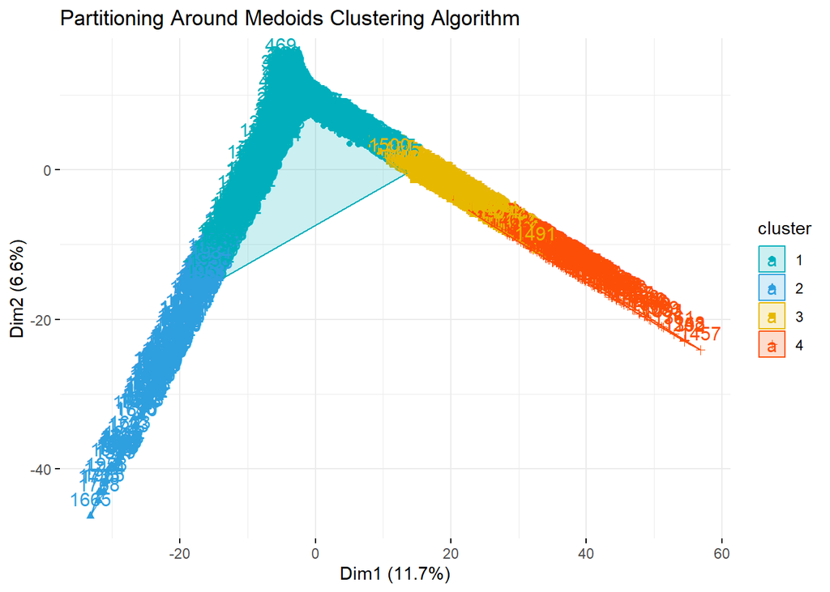

```r
fviz_cluster(pam_fit, data = raw_data,
             palette = c("#00AFBB","#2E9FDF", "#E7B800", "#FC4E07"),
             ggtheme = theme_minimal(),
             main = "Partitioning Around Medoids Clustering Algorithm"
             )
```

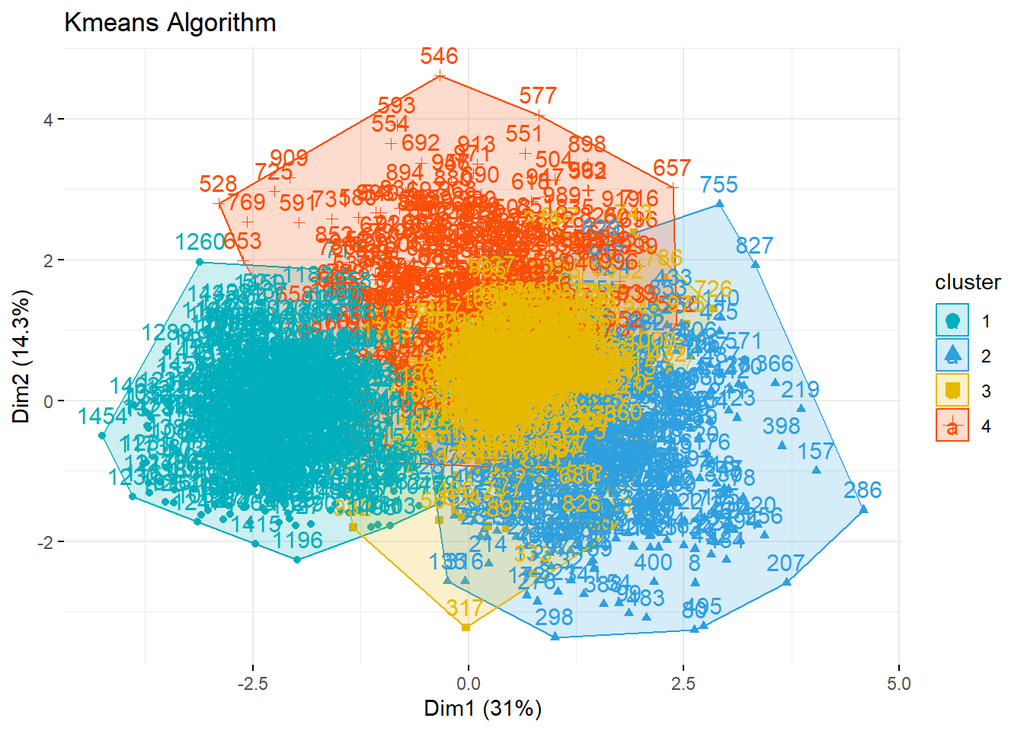

```r
fviz_cluster(k_means_fit, data = raw_data,
             palette = c("#00AFBB","#2E9FDF", "#E7B800", "#FC4E07"),
             ggtheme = theme_minimal(),
             main = "Kmeans Algorithm"
             )
```

4- Compute sample mean vector and sample covariance matrix for each cluster from three clustering strategies and compare with the parameters you used to generate the synthetic data.

```r
## for PAM

for(i in 1:4){
  temp <- data_combined[data_combined$pam_clusters==i,]%>%select(-c(wards_clusters,kmeans_clusters,pam_clusters))
  print(paste0("For Cluster ",i))
  print(colMeans(temp))
  print(cov(temp))
  cat("\n")

}
```

```
## [1] "For Cluster 1"
##    var_1    var_2    var_3    var_4    var_5    var_6    var_7    var_8
## 3.971679 4.064763 3.490735 3.372149 2.938867 4.231952 2.870979 2.163720
##             var_1       var_2       var_3      var_4       var_5       var_6
## var_1  4.45529550  0.99270470  0.32813665  0.1572080 -0.45914748  0.86711773
## var_2  0.99270470  6.25844376  0.65635820 -0.5123205 -1.16137751  0.06002154
## var_3  0.32813665  0.65635820  3.87212882 -0.1251089 -0.50987241 -0.09777486
## var_4  0.15720804 -0.51232054 -0.12510886  3.7482406  0.45660020  0.35510957
## var_5 -0.45914748 -1.16137751 -0.50987241  0.4566002  4.70399965  0.95518682
## var_6  0.86711773  0.06002154 -0.09777486  0.3551096  0.95518682  6.44943572
## var_7  0.04450963 -0.09242868 -0.13455971 -0.1620244 -0.03488361 -0.01801364
## var_8 -0.77746385 -1.59324427 -0.53414667  0.1894158  0.92214008 -0.10078975
##               var_7         var_8
## var_1  0.0445096334 -0.7774638535
## var_2 -0.0924286751 -1.5932442730
## var_3 -0.1345597081 -0.5341466723
## var_4 -0.1620243996  0.1894158334
## var_5 -0.0348836122  0.9221400840
## var_6 -0.0180136388 -0.1007897507
## var_7  3.5423013880  0.0006715843
## var_8  0.0006715843  4.7291512922
##
## [1] "For Cluster 2"
##    var_1    var_2    var_3    var_4    var_5    var_6    var_7    var_8
## 3.948280 3.859644 4.098076 3.836835 2.975997 2.937878 1.742339 1.750034
##              var_1         var_2         var_3         var_4         var_5
## var_1  0.635294457  0.0062706780  0.0730071632 -2.258049e-02 -0.0079164738
## var_2  0.006270678  0.4820475655 -0.0001663444 -4.261612e-02  0.0005080264
## var_3  0.073007163 -0.0001663444  0.5407238716  8.179847e-03  0.0138987684
## var_4 -0.022580487 -0.0426161244  0.0081798469  6.277263e-01  0.0198553337
## var_5 -0.007916474  0.0005080264  0.0138987684  1.985533e-02  0.5477932012
## var_6  0.041281036  0.0168836941 -0.0333123658  2.011334e-02 -0.0054970111
## var_7 -0.088235370  0.0094350253 -0.0173529372 -4.456137e-05  0.0125248746
## var_8 -0.028701984 -0.0468687710  0.0366263068  7.788028e-02 -0.0251571387
##              var_6         var_7        var_8
## var_1  0.041281036 -8.823537e-02 -0.028701984
## var_2  0.016883694  9.435025e-03 -0.046868771
## var_3 -0.033312366 -1.735294e-02  0.036626307
## var_4  0.020113335 -4.456137e-05  0.077880284
## var_5 -0.005497011  1.252487e-02 -0.025157139
```

[output cut: 32 more lines]

```
## var_3 -0.27108403 -0.07551030  1.06419942 -0.09103920 -0.10709970  0.01368349
## var_4 -0.02440182  0.12691727 -0.09103920  1.31955497  0.08000092  0.07650797
## var_5  0.05084896 -0.04849958 -0.10709970  0.08000092  1.27456020  0.03254153
## var_6 -0.09121617  0.05688205  0.01368349  0.07650797  0.03254153  1.35996754
## var_7  0.03989618  0.16515626  0.03227576 -0.04661012 -0.24309524  0.02790548
## var_8  0.10156647  0.05910547 -0.09599139 -0.01225302  0.01465762 -0.09135540
##             var_7       var_8
## var_1  0.03989618  0.10156647
## var_2  0.16515626  0.05910547
## var_3  0.03227576 -0.09599139
## var_4 -0.04661012 -0.01225302
## var_5 -0.24309524  0.01465762
## var_6  0.02790548 -0.09135540
## var_7  1.79412616 -0.12576600
## var_8 -0.12576600  0.93861312
```

```r
## for Wards

for(i in 1:4){
  temp <- data_combined[data_combined$wards_clusters==i,]%>%select(-c(wards_clusters,kmeans_clusters,pam_clusters))
  print(paste0("For Cluster ",i))
  print(colMeans(temp))
  print(cov(temp))
  cat("\n")

}
```

```
## [1] "For Cluster 1"
##    var_1    var_2    var_3    var_4    var_5    var_6    var_7    var_8
## 3.988711 4.331838 3.475348 3.161636 2.715582 4.070031 2.977323 2.101735
##             var_1      var_2       var_3       var_4       var_5      var_6
## var_1  5.24041048  1.3173203  0.41889662  0.19616858 -0.59350009  0.9695349
## var_2  1.31732034  6.4871243  0.55232782 -0.35869945 -0.74161871  1.3781799
## var_3  0.41889662  0.5523278  4.26944278 -0.17366449 -0.42090686  0.3505667
## var_4  0.19616858 -0.3586995 -0.17366449  4.05964642  0.36157145  0.2981465
## var_5 -0.59350009 -0.7416187 -0.42090686  0.36157145  4.86403863  0.2239166
## var_6  0.96953493  1.3781799  0.35056675  0.29814645  0.22391660  5.6388929
## var_7  0.03106013 -0.1557867 -0.09574165 -0.07276379 -0.06896211 -0.1736030
## var_8 -1.04148809 -1.5839549 -0.47924252  0.15785868  0.86852263 -0.7263356
##             var_7       var_8
## var_1  0.03106013 -1.04148809
## var_2 -0.15578673 -1.58395493
## var_3 -0.09574165 -0.47924252
## var_4 -0.07276379  0.15785868
## var_5 -0.06896211  0.86852263
## var_6 -0.17360302 -0.72633561
## var_7  3.99062769 -0.06507917
## var_8 -0.06507917  5.36504307
##
## [1] "For Cluster 2"
##    var_1    var_2    var_3    var_4    var_5    var_6    var_7    var_8
## 3.876578 3.986166 4.107942 3.988231 2.962360 2.939635 1.969486 1.795625
##               var_1        var_2         var_3        var_4        var_5
## var_1  0.7978079300 -0.085422122 -0.0007263147  0.012748769 -0.010963040
## var_2 -0.0854221218  0.912074747  0.0144075106  0.013615217  0.003280297
## var_3 -0.0007263147  0.014407511  0.7703607292  0.054097587  0.033508750
## var_4  0.0127487688  0.013615217  0.0540975870  0.926644785  0.010664106
## var_5 -0.0109630403  0.003280297  0.0335087502  0.010664106  0.823793239
## var_6 -0.0224610283  0.060105941  0.0519037691 -0.002549698  0.023626243
## var_7 -0.0237598701  0.047892028  0.0486495546 -0.002227948  0.085974206
## var_8  0.0368393148 -0.133988325 -0.0155584039  0.140810942 -0.001500347
##              var_6        var_7        var_8
## var_1 -0.022461028 -0.023759870  0.036839315
## var_2  0.060105941  0.047892028 -0.133988325
## var_3  0.051903769  0.048649555 -0.015558404
## var_4 -0.002549698 -0.002227948  0.140810942
## var_5  0.023626243  0.085974206 -0.001500347
```

[output cut: 32 more lines]

```
## var_3 -0.26924213  0.10424289  1.08722089 -0.0894932069 -0.10164579  0.02663412
## var_4  0.04050265  0.25808600 -0.08949321  1.3628415359  0.07406344  0.06114980
## var_5  0.07551530 -0.02748828 -0.10164579  0.0740634422  1.11698390  0.16630655
## var_6  0.03137568  0.07915091  0.02663412  0.0611497978  0.16630655  1.21182895
## var_7  0.03230570  0.14028738  0.07946816 -0.0005924174 -0.18315939  0.10412116
## var_8  0.03541849 -0.02400204 -0.08845897 -0.0331921656  0.04018386 -0.08895979
##               var_7       var_8
## var_1  0.0323057019  0.03541849
## var_2  0.1402873758 -0.02400204
## var_3  0.0794681600 -0.08845897
## var_4 -0.0005924174 -0.03319217
## var_5 -0.1831593903  0.04018386
## var_6  0.1041211612 -0.08895979
## var_7  1.8859739642 -0.07698069
## var_8 -0.0769806880  1.00008066
```

```r
## for Kmeans

for(i in 1:4){
  temp <- data_combined[data_combined$kmeans_clusters==i,]%>%select(-c(wards_clusters,kmeans_clusters,pam_clusters))
  print(paste0("For Cluster ",i))
  print(colMeans(temp))
  print(cov(temp))
  cat("\n")

}
```

```
## [1] "For Cluster 1"
##    var_1    var_2    var_3    var_4    var_5    var_6    var_7    var_8
## 3.911539 1.167724 2.133289 5.035695 6.012320 8.868638 2.919313 3.973891
##             var_1        var_2        var_3       var_4       var_5       var_6
## var_1  2.25365939 -0.103675314 -0.077606040 -0.03006722 -0.05988500  0.07499904
## var_2 -0.10367531  2.366263308 -0.009315656  0.03663804  0.03321067 -0.14317108
## var_3 -0.07760604 -0.009315656  2.321509036 -0.10892820 -0.01167175  0.17248678
## var_4 -0.03006722  0.036638041 -0.108928203  2.21015077  0.20056888 -0.03131450
## var_5 -0.05988500  0.033210667 -0.011671749  0.20056888  2.12462108 -0.05186254
## var_6  0.07499904 -0.143171081  0.172486776 -0.03131450 -0.05186254  2.29183944
## var_7  0.05359606  0.049261959  0.092840987 -0.03081740  0.03813882  0.07674904
## var_8  0.08901372  0.050648927 -0.070769561  0.03746038  0.02867997  0.08270465
##             var_7       var_8
## var_1  0.05359606  0.08901372
## var_2  0.04926196  0.05064893
## var_3  0.09284099 -0.07076956
## var_4 -0.03081740  0.03746038
## var_5  0.03813882  0.02867997
## var_6  0.07674904  0.08270465
## var_7  2.12296341 -0.02899748
## var_8 -0.02899748  2.01007488
##
## [1] "For Cluster 2"
##     var_1     var_2     var_3     var_4     var_5     var_6     var_7     var_8
## 5.1123476 6.2343496 3.9315054 2.7286584 1.7793548 5.1476108 3.1515426 0.6900186
##             var_1       var_2       var_3       var_4       var_5       var_6
## var_1  3.93338567 -0.39248366 -0.19632167  0.37694922  0.02821068 -0.22342299
## var_2 -0.39248366  3.71086660  0.07887933  0.42337049  0.20088669 -0.28223552
## var_3 -0.19632167  0.07887933  4.18363819 -0.11161867  0.01354540  0.05928688
## var_4  0.37694922  0.42337049 -0.11161867  3.86002114 -0.08689519  0.45845916
## var_5  0.02821068  0.20088669  0.01354540 -0.08689519  3.55002104  0.51220366
## var_6 -0.22342299 -0.28223552  0.05928688  0.45845916  0.51220366  3.41165320
## var_7  0.12550838 -0.35268730 -0.13750904  0.05810707  0.15865442 -0.37382240
## var_8  0.24191114  0.45020454 -0.17088441 -0.39456411  0.03132665  0.22456247
##             var_7       var_8
## var_1  0.12550838  0.24191114
## var_2 -0.35268730  0.45020454
## var_3 -0.13750904 -0.17088441
## var_4  0.05810707 -0.39456411
## var_5  0.15865442  0.03132665
```

[output cut: 32 more lines]

```
## var_3 -0.84968462 -0.3508390  4.59243832 -0.31207330 -0.03212306  0.06598756
## var_4 -0.03442482 -0.3836231 -0.31207330  3.75324009 -0.20596739 -0.18743748
## var_5 -0.27723659  0.2250569 -0.03212306 -0.20596739  5.15963513  0.06914797
## var_6 -0.23906991  0.2381338  0.06598756 -0.18743748  0.06914797  4.31456664
## var_7  0.83392556  0.6353411  0.12934596  0.64277417 -0.16540016  0.41007144
## var_8  0.38999331 -0.1056137  0.38555249  0.59868094  0.46179626  0.48596970
##            var_7      var_8
## var_1  0.8339256  0.3899933
## var_2  0.6353411 -0.1056137
## var_3  0.1293460  0.3855525
## var_4  0.6427742  0.5986809
## var_5 -0.1654002  0.4617963
## var_6  0.4100714  0.4859697
## var_7  3.8555653 -0.4515194
## var_8 -0.4515194  4.1906883
```

```r
data_combined %>%
  count(wards_clusters==1,wards_clusters==2,wards_clusters==3,wards_clusters==4)
```

```
##   wards_clusters == 1 wards_clusters == 2 wards_clusters == 3
## 1               FALSE               FALSE               FALSE
## 2               FALSE               FALSE                TRUE
## 3               FALSE                TRUE               FALSE
## 4                TRUE               FALSE               FALSE
##   wards_clusters == 4    n
## 1                TRUE  144
## 2               FALSE  308
## 3               FALSE  411
## 4               FALSE 1137
```

```r
data_combined %>%
  count(pam_clusters==1,pam_clusters==2,pam_clusters==3,pam_clusters==4)
```

```
##   pam_clusters == 1 pam_clusters == 2 pam_clusters == 3 pam_clusters == 4    n
## 1             FALSE             FALSE             FALSE              TRUE  161
## 2             FALSE             FALSE              TRUE             FALSE  194
## 3             FALSE              TRUE             FALSE             FALSE  215
## 4              TRUE             FALSE             FALSE             FALSE 1430
```

```r
data_combined %>%
  count(kmeans_clusters==1,kmeans_clusters==2,kmeans_clusters==3,kmeans_clusters==4)
```

```
##   kmeans_clusters == 1 kmeans_clusters == 2 kmeans_clusters == 3
## 1                FALSE                FALSE                FALSE
## 2                FALSE                FALSE                 TRUE
## 3                FALSE                 TRUE                FALSE
## 4                 TRUE                FALSE                FALSE
##   kmeans_clusters == 4   n
## 1                 TRUE 308
## 2                FALSE 719
## 3                FALSE 447
## 4                FALSE 526
```

It can be seen that partitioning around medoids clustering algorithm and hierarchical clustering with Ward’s method have resulted with different clusterings compared to Kmeans approach.

5- Compare the performance of the proposed strategies when we introduce additional noise variables from Bernoulli distribution up to 8 variables.

```r
noise_data <- matrix(rbinom(8*2000, 1, 0.5), ncol = 8)
data_combined_v2 <- cbind(raw_data,noise_data)
```

```r
fit <- randomForest(data_combined_v2, proximity = TRUE)
proximity_matrix <- fit$proximity
```

```r
dissimilarity_matrix <- 1-proximity_matrix
pam_fit <- pam(dissimilarity_matrix,k=4)


# Ward’s Method #
wards_fit<-hclust(dist(dissimilarity_matrix),method='ward.D')
profiling_wards<-cutree(wards_fit,4)

k_means_fit <- kmeans(data_combined, centers = 4)

data_combined_v2 <- cbind(data_combined_v2,pam_clusters=pam_fit$clustering)
data_combined_v2 <- cbind(data_combined_v2,wards_clusters=profiling_wards)
data_combined_v2 <- cbind(data_combined_v2,kmeans_clusters=k_means_fit$cluster)
```

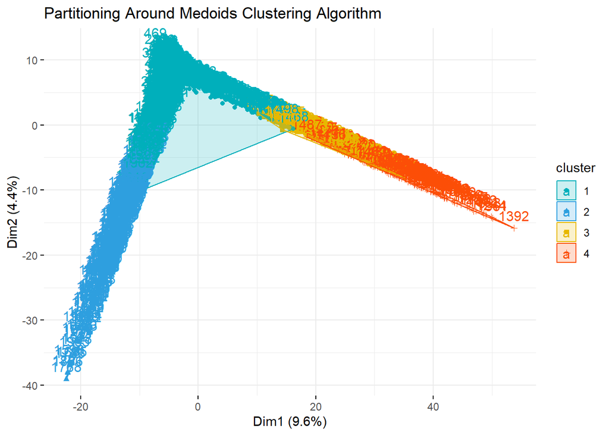

```r
fviz_cluster(pam_fit, data = raw_data,
             palette = c("#00AFBB","#2E9FDF", "#E7B800", "#FC4E07"),
             ggtheme = theme_minimal(),
             main = "Partitioning Around Medoids Clustering Algorithm"
             )
```

[figure not shown]

```r
fviz_cluster(k_means_fit, data = raw_data,
             palette = c("#00AFBB","#2E9FDF", "#E7B800", "#FC4E07"),
             ggtheme = theme_minimal(),
             main = "Kmeans Algorithm"
             )
```

```r
## for PAM

for(i in 1:4){
  temp <- data_combined_v2[data_combined_v2$pam_clusters==i,]%>%select(-c(wards_clusters,kmeans_clusters,pam_clusters))
  print(paste0("For Cluster ",i))
  print(colMeans(temp))
  print(cov(temp))
  cat("\n")

}
```

```
## [1] "For Cluster 1"
##     var_1     var_2     var_3     var_4     var_5     var_6     var_7     var_8
## 3.9619481 4.0187708 3.4132657 3.3381519 2.9688362 4.3921568 2.9355439 2.2119771
##         1         2         3         4         5         6         7         8
## 0.5188749 0.5099926 0.5085122 0.5159141 0.4937084 0.5048113 0.4944486 0.5055514
##              var_1        var_2        var_3        var_4        var_5
## var_1  4.708595127  1.072079858  0.362894672  0.156674349 -0.539371023
## var_2  1.072079858  6.683339002  0.752375647 -0.583894129 -1.306150168
## var_3  0.362894672  0.752375647  4.109755269 -0.212104399 -0.591859601
## var_4  0.156674349 -0.583894129 -0.212104399  3.923480289  0.542134724
## var_5 -0.539371023 -1.306150168 -0.591859601  0.542134724  4.993088398
## var_6  0.850647609 -0.093948266 -0.186993320  0.546628635  1.167938251
## var_7  0.045605343 -0.072425001 -0.074514954 -0.107201565 -0.056403343
## var_8 -0.847476585 -1.813639435 -0.637940478  0.272674643  1.089750416
## 1      0.024368905  0.038698322 -0.002963120 -0.018309373 -0.037489170
## 2     -0.029730452  0.016210929 -0.029413585  0.007976233  0.006691195
## 3      0.010237935  0.027497635 -0.038958774 -0.045808540 -0.020375605
## 4     -0.011856080 -0.064343407 -0.015519145  0.045277801  0.077339002
## 5     -0.012802827 -0.045934387 -0.044033553 -0.001336712  0.033536562
## 6     -0.015014028 -0.006867597  0.021222563  0.011487905  0.025270459
## 7     -0.008819916 -0.024588694 -0.044836292  0.029777178  0.011838995
## 8     -0.034639682  0.050923227  0.005943319  0.005988708  0.023305760
##             var_6        var_7         var_8            1             2
## var_1  0.85064761  0.045605343 -0.8474765852  0.024368905 -0.0297304522
## var_2 -0.09394827 -0.072425001 -1.8136394349  0.038698322  0.0162109286
## var_3 -0.18699332 -0.074514954 -0.6379404784 -0.002963120 -0.0294135851
## var_4  0.54662864 -0.107201565  0.2726746427 -0.018309373  0.0079762325
## var_5  1.16793825 -0.056403343  1.0897504163 -0.037489170  0.0066911954
## var_6  6.99055248 -0.134973528  0.0776470628 -0.044829527  0.0264301688
## var_7 -0.13497353  3.631502906 -0.0233175883 -0.023961930  0.0350977102
## var_8  0.07764706 -0.023317588  5.0648394095 -0.054821842  0.0051393033
## 1     -0.04482953 -0.023961930 -0.0548218420  0.249828659  0.0055519917
## 2      0.02643017  0.035097710  0.0051393033  0.005551992  0.2500852592
## 3     -0.02086778 -0.023528270 -0.0026359514  0.003357732  0.0086185816
## 4      0.01845732  0.065767830  0.0003788504 -0.007152452 -0.0003443266
## 5     -0.02066274  0.026464230  0.0357969687 -0.004510788  0.0058036571
## 6      0.01746489 -0.005695862 -0.0137291642 -0.002868657  0.0090259616
## 7      0.02979270  0.031993312  0.0235570497 -0.010080325  0.0054258848
## 8      0.07068642 -0.010969495 -0.0312038062 -0.005475231  0.0027222633
##                  3             4            5            6            7
```

[output cut: 240 more lines]

```
## var_2  0.059518654
## var_3  0.003883006
## var_4  0.019601875
## var_5 -0.040750834
## var_6  0.055341731
## var_7  0.022973771
## var_8  0.030987228
## 1      0.017234262
## 2     -0.013312693
## 3      0.016099071
## 4      0.030546956
## 5     -0.012796698
## 6      0.001547988
## 7     -0.019401445
## 8      0.251393189
```

```r
## for Wards

for(i in 1:4){
  temp <- data_combined_v2[data_combined_v2$wards_clusters==i,]%>%select(-c(wards_clusters,kmeans_clusters,pam_clusters))
  print(paste0("For Cluster ",i))
  print(colMeans(temp))
  print(cov(temp))
  cat("\n")

}
```

```
## [1] "For Cluster 1"
##     var_1     var_2     var_3     var_4     var_5     var_6     var_7     var_8
## 3.9447737 4.1357012 3.3991594 3.1829471 2.7737088 4.3307879 3.0098375 2.1835996
##         1         2         3         4         5         6         7         8
## 0.5123457 0.5149912 0.5035273 0.5123457 0.5017637 0.4920635 0.4955908 0.5017637
##              var_1        var_2        var_3        var_4        var_5
## var_1  5.288713114  1.318877874  0.460933824  0.180894457 -0.647315872
## var_2  1.318877874  7.131140401  0.569285624 -0.469590750 -1.157713704
## var_3  0.460933824  0.569285624  4.135327038 -0.150798269 -0.490159150
## var_4  0.180894457 -0.469590750 -0.150798269  4.021396872  0.430346982
## var_5 -0.647315872 -1.157713704 -0.490159150  0.430346982  5.159986496
## var_6  1.064473359  0.575148252  0.270649964  0.433006484  0.800072807
## var_7  0.070669902 -0.058961075 -0.034344901 -0.109911374 -0.034319577
## var_8 -1.021960947 -1.839290450 -0.495399098  0.195648077  1.027660775
## 1      0.023791269  0.042956191 -0.016087241 -0.033018519 -0.036848820
## 2     -0.022908980  0.025496872 -0.009537729  0.014926600 -0.009923453
## 3      0.009563536  0.041076288 -0.035697550 -0.061427605 -0.012626352
## 4     -0.023199635 -0.066704751 -0.002462732  0.061121616  0.080908332
## 5     -0.012922508 -0.049276186 -0.051045356  0.026786225  0.025027098
## 6     -0.017866588  0.005230471  0.028569140 -0.018094825 -0.007869951
## 7      0.004280208 -0.019488692 -0.030771729  0.018937223 -0.006810380
## 8     -0.047659847  0.062306225 -0.002680662  0.003407699  0.013205194
##              var_6       var_7         var_8            1            2
## var_1  1.064473359  0.07066990 -1.0219609467  0.023791269 -0.022908980
## var_2  0.575148252 -0.05896107 -1.8392904504  0.042956191  0.025496872
## var_3  0.270649964 -0.03434490 -0.4953990983 -0.016087241 -0.009537729
## var_4  0.433006484 -0.10991137  0.1956480772 -0.033018519  0.014926600
## var_5  0.800072807 -0.03431958  1.0276607754 -0.036848820 -0.009923453
## var_6  6.729416544 -0.25905364 -0.4019628902 -0.052996176  0.011175375
## var_7 -0.259053636  3.97216196 -0.0700918720 -0.012511882  0.034190990
## var_8 -0.401962890 -0.07009187  5.4954448021 -0.045216447 -0.020084645
## 1     -0.052996176 -0.01251188 -0.0452164466  0.250068103  0.004227823
## 2      0.011175375  0.03419099 -0.0200846451  0.004227823  0.249995719
## 3     -0.008421128 -0.02675907 -0.0084185526  0.004810783  0.008773200
## 4      0.022981488  0.08302064  0.0005660054 -0.007654757 -0.001950465
## 5     -0.016494574  0.02489092  0.0510867029 -0.001345712  0.002621375
## 6     -0.008042411 -0.00415466 -0.0088133686 -0.007845445  0.008503902
## 7      0.017965900  0.02770823  0.0301489898 -0.011419481  0.007568364
## 8      0.074574749 -0.01948448 -0.0377185429 -0.003993549  0.004386600
##                   3             4             5            6            7
```

[output cut: 223 more lines]

```
## var_2  0.028896950 -0.047669270  0.035148124  0.046937610  0.129646059
## var_3  0.029751761 -0.013141174  0.001254024 -0.112507434  0.022338203
## var_4 -0.081401287  0.023529820  0.072433740  0.027301048  0.051204207
## var_5  0.033605527 -0.023914576  0.002131790  0.012262293 -0.090403209
## var_6  0.012349371 -0.036481537 -0.040051368 -0.019128039  0.032067700
## var_7  0.009070725  0.030027229  0.078097099  0.012228454  0.039531834
## var_8  0.007843980  0.008475976 -0.011337300 -0.001898995  0.027124031
## 1     -0.017458734  0.031743153  0.032468710  0.023081807  0.002448757
## 2      0.021449302  0.008298567 -0.001859242  0.034962815 -0.020769091
## 3      0.008207872 -0.020451660 -0.015282061  0.021721386  0.019136586
## 4      0.251587158  0.019227281  0.005033557 -0.005169599  0.052602939
## 5      0.019227281  0.247596590  0.001904589 -0.021313260 -0.020088881
## 6      0.005033557  0.001904589  0.251677852  0.011790314  0.035552331
## 7     -0.005169599 -0.021313260  0.011790314  0.251587158 -0.001451116
## 8      0.052602939 -0.020088881  0.035552331 -0.001451116  0.251133684
```

```r
## for Kmeans

for(i in 1:4){
  temp <- data_combined_v2[data_combined_v2$kmeans_clusters==i,]%>%select(-c(wards_clusters,kmeans_clusters,pam_clusters))
  print(paste0("For Cluster ",i))
  print(colMeans(temp))
  print(cov(temp))
  cat("\n")

}
```

```
## [1] "For Cluster 1"
##     var_1     var_2     var_3     var_4     var_5     var_6     var_7     var_8
## 3.9173111 1.1449379 2.1406197 5.0276507 6.0303841 8.8859745 2.9237765 3.9812833
##         1         2         3         4         5         6         7         8
## 0.5325670 0.5038314 0.5019157 0.5095785 0.5306513 0.4904215 0.5210728 0.5440613
##               var_1        var_2        var_3         var_4        var_5
## var_1  2.2577290717 -0.092154468 -0.079386574 -0.0338992469 -0.077810510
## var_2 -0.0921544683  2.297754332  0.004548694  0.0268133761  0.093374928
## var_3 -0.0793865743  0.004548694  2.314004171 -0.0938721841 -0.020959497
## var_4 -0.0338992469  0.026813376 -0.093872184  2.1716795542  0.208499618
## var_5 -0.0778105099  0.093374928 -0.020959497  0.2084996180  2.092305409
## var_6  0.0673099762 -0.104558138  0.150113652  0.0180158428 -0.084515848
## var_7  0.0454099477  0.057647464  0.084539471 -0.0353389301  0.027525679
## var_8  0.0810871306  0.058243816 -0.097321158  0.0463173652  0.018115517
## 1     -0.0179990817  0.002542343 -0.013884791  0.0131561242 -0.030596591
## 2     -0.0491704318 -0.064237416 -0.040510912 -0.0592493728  0.007094461
## 3     -0.0153869060 -0.001903978 -0.052647131  0.0273466594 -0.017830524
## 4     -0.0073859967 -0.008781370  0.042800824 -0.0270550131  0.003956591
## 5     -0.0052321896 -0.016522545 -0.066343487  0.0004598513  0.019579706
## 6      0.0008044298  0.045834818 -0.015759491  0.0163717599 -0.035260924
## 7     -0.0582137563  0.043664882 -0.088444843  0.0450009888  0.013823550
## 8      0.0077861977  0.031181814  0.001081413  0.0140231225 -0.037673819
##               var_6        var_7        var_8             1            2
## var_1  0.0673099762  0.045409948  0.081087131 -0.0179990817 -0.049170432
## var_2 -0.1045581382  0.057647464  0.058243816  0.0025423429 -0.064237416
## var_3  0.1501136519  0.084539471 -0.097321158 -0.0138847908 -0.040510912
## var_4  0.0180158428 -0.035338930  0.046317365  0.0131561242 -0.059249373
## var_5 -0.0845158477  0.027525679  0.018115517 -0.0305965913  0.007094461
## var_6  2.2484455515  0.071343399  0.062513672  0.0448064618 -0.009388316
## var_7  0.0713433994  2.129626265 -0.044575290 -0.0368969364  0.002260399
## var_8  0.0625136717 -0.044575290  1.991521110 -0.0346597687  0.022610227
## 1      0.0448064618 -0.036896936 -0.034659769  0.2494171980  0.011391297
## 2     -0.0093883157  0.002260399  0.022610227  0.0113912973  0.250465139
## 3     -0.0008211277 -0.048995862  0.028668480  0.0008971842  0.011508961
## 4     -0.0120744545  0.006307333  0.008437796 -0.0147079371  0.007640773
## 5     -0.0433314186  0.068215561  0.028795762  0.0105161751  0.014277730
## 6     -0.0345653373  0.060562844  0.021101526  0.0147079371 -0.007640773
## 7     -0.0321094746  0.031829930 -0.015067688 -0.0093248321  0.013354807
## 8      0.0126000935  0.025844710 -0.004271879  0.0014413778  0.015185945
##                   3            4             5             6             7
```

[output cut: 240 more lines]

```
## var_2  0.1112289147
## var_3  0.0780231246
## var_4 -0.0072490224
## var_5  0.0744757908
## var_6 -0.0559338605
## var_7 -0.0354530514
## var_8  0.0244171423
## 1     -0.0008037565
## 2     -0.0179153094
## 3     -0.0010787258
## 4      0.0127754981
## 5     -0.0025699057
## 6     -0.0190151868
## 7     -0.0025699057
## 8      0.2490270316
```

After introducing the noise data, the performances of the approaches hasn’t significantly changed.

```r
data_combined_v2 %>%
  count(wards_clusters==1,wards_clusters==2,wards_clusters==3,wards_clusters==4)
```

```
##   wards_clusters == 1 wards_clusters == 2 wards_clusters == 3
## 1               FALSE               FALSE               FALSE
## 2               FALSE               FALSE                TRUE
## 3               FALSE                TRUE               FALSE
## 4                TRUE               FALSE               FALSE
##   wards_clusters == 4    n
## 1                TRUE  149
## 2               FALSE  245
## 3               FALSE  472
## 4               FALSE 1134
```

```r
data_combined_v2 %>%
  count(pam_clusters==1,pam_clusters==2,pam_clusters==3,pam_clusters==4)
```

```
##   pam_clusters == 1 pam_clusters == 2 pam_clusters == 3 pam_clusters == 4    n
## 1             FALSE             FALSE             FALSE              TRUE  171
## 2             FALSE             FALSE              TRUE             FALSE  159
## 3             FALSE              TRUE             FALSE             FALSE  319
## 4              TRUE             FALSE             FALSE             FALSE 1351
```

```r
data_combined_v2 %>%
  count(kmeans_clusters==1,kmeans_clusters==2,kmeans_clusters==3,kmeans_clusters==4)
```

```
##   kmeans_clusters == 1 kmeans_clusters == 2 kmeans_clusters == 3
## 1                FALSE                FALSE                FALSE
## 2                FALSE                FALSE                 TRUE
## 3                FALSE                 TRUE                FALSE
## 4                 TRUE                FALSE                FALSE
##   kmeans_clusters == 4   n
## 1                 TRUE 308
## 2                FALSE 721
## 3                FALSE 449
## 4                FALSE 522
```

-> Random Forests provides effective solutions for various problems. However, in high dimensionality, the data becomes sparse in its state space and density and distance between points, become less meaningful (the curse of dimensionality) and random forest algorithm may overfit or fail to explain the relationship between variables and its performance may decrease. In such cases, dimensionality reduction can be the solution.